# 비선형 분류기

## 의사결정나무

**의사결정나무(decision tree)**는 특징변수 $x_1, x_2,... x_d$로 이루어진 $d$-차원 공간을 재귀적으로 분할해 얻은 (직사각형) 영역 $R_1, R_2,..., R_M$을 예측에 사용하는 방법이다. 각 분할(split)에서는 예측변수 중 하나만을 기준으로 사용되는데, 분할 규칙은 분할 후 영역 내의 동질성(homogeneity)를 최대로 하는 방식을 따른다.

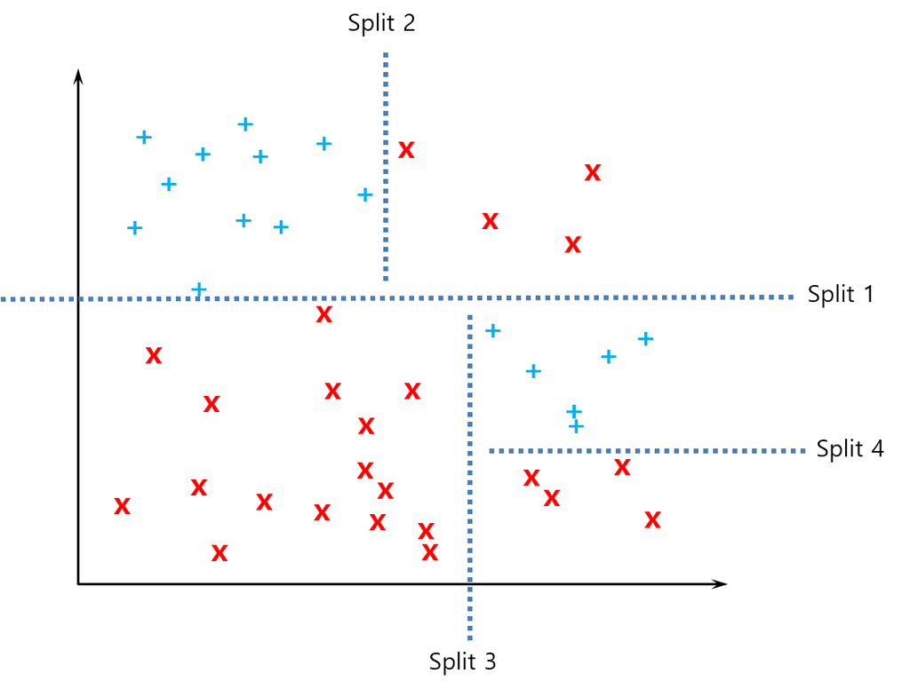

**예제** (Brandon Rohrer 유튜브 강의 영상 참고) https://youtu.be/9w16p4QmkAI

- 학습데이터

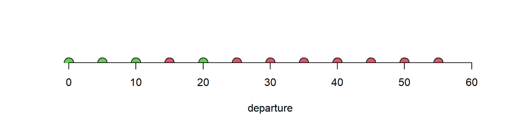

- [**Split 1**] 8:23분 전에 출발?
  - Yes: 대체로 정시 도착
  - No: 확실히 지각 도착

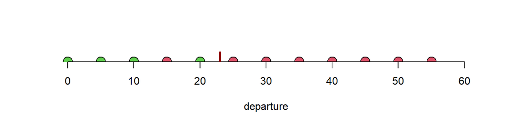

- [Split 1] 8:23분 전에 출발?
  - Yes:

    [**Split 2**] 8:13 전에 출발?
    - Yes: 확실히 정시 도착
    - No: 반반
  - No: 확실히 지각 도착

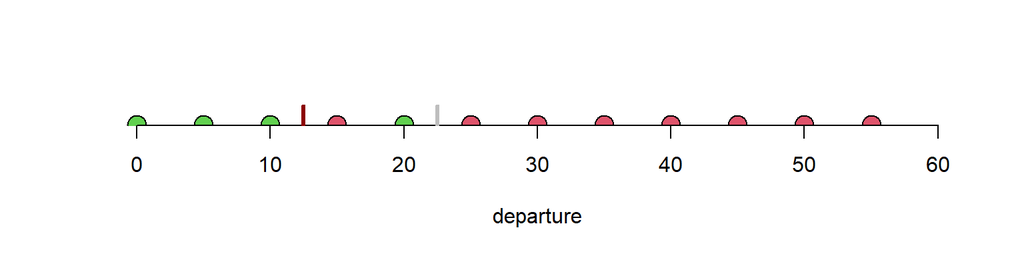

- [Split 1] 8:23분 전에 출발?
  - Yes: 대체로 정시 도착

    [Split 2] 8:13 전에 출발?
    - Yes: 확실히 정시 도착
    - No:

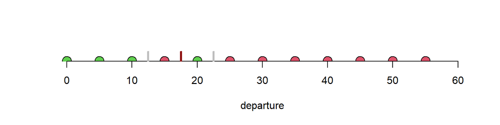

$\Box$

의사결정나무를 학습시키는 것은 학습데이터를 이용해 분리 규칙을 도출하는 것이다. 이를 위해 사용하는 측도들은 다음과 같다.

- 오분류율: 각 영역 내 오분류율 계산
- Gini impurity: 각 영역 내 클래스별 상대도수를 $p(k)$라 하면
  $$G(p) = \sum_{k=1}^K p(k) (1-p(k)) = 1 - \sum_{k=1}^K p(k)^2$$
  - $p(k)$들이 0 또는 1 에 가까워지면 $G$의 값이 작아짐
- Cross-entropy
  $$D(p) = -\sum_{k=1}^K p(k)\log p(k)$$
  - Gini impurity와 같은 성격: $p(k)$들이 0 또는 1 에 가까워지면 $D(p)$의 값이 작아짐
- Information gain: Split에 의한 Entropy 감소량을 최대로 하는 방법
  $$IG(p, a) = D(p) - D(p|a)$$
  단, $D(p|a) = -\sum_a P(a) \sum_{k=1}^K p(k|a)\log_2 p(k|a)$는 split 후 엔트로피의 가중합
- Variance reduction: (전체 영역을 대상으로 구한 분산) - (Split된 영역 내 분산의 합) 을 최대로 하는 splitting rule 을 찾음

최신 분류기에 비해 다소 예측력은 떨어지지만 도출된 분할 규칙이 이해하기 쉽고 해석이 용이하기 때문에 널리 사용되고 있다.

### 예제 데이터 분석: `adult`

데이터 읽기

```r
adult <- read.csv(file = "./dat/adult.csv", stringsAsFactors = TRUE)
```

훈련데이터와 시험데이터 쪼개기 (70:30)

```r
set.seed(0)
N <- nrow(adult)
adult$grp <- runif(N)
p.tr <- 0.7

library(dplyr)
adult.tr <- adult %>% filter(grp <= p.tr)
adult.te <- adult %>% filter(grp > p.tr)
```

의사결정나무 학습: `rpart` 패키지의 `rpart()` 사용

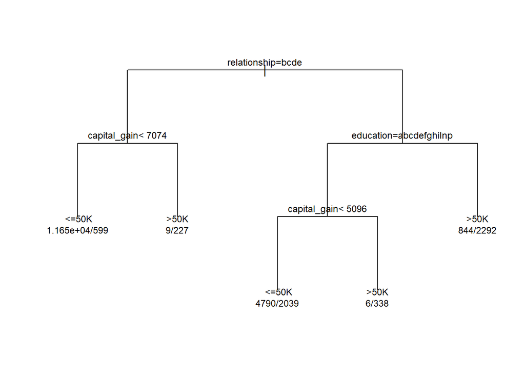

```r
library(rpart)
tree.fit <- rpart(wage ~ ., data = adult.tr)

par(xpd = TRUE)
plot(tree.fit, uniform = TRUE)
text(tree.fit, use.n = TRUE, cex = 0.75)
```

예측 성능 확인

```r
harmonic.mean <- function(a, b) 2*a*b/(a+b)

accuracyMeasures <- function(pred, truth, cutoff = 0.5) {
  ctable <- table(Actual = truth,
                  Predicted = 1*(pred >= cutoff))
  cat("Confusion matrix: \n")
  print(ctable)
  cat("\n")
  accuracy <- round(sum(diag(ctable))/sum(ctable), 4)
  specificity <- round(ctable[1, 1]/sum(ctable[1,]), 4)
  precision <- round(ctable[2, 2]/sum(ctable[,2]), 4)
  recall <- round(ctable[2, 2]/sum(ctable[2,]), 4)
  f1 <- round(harmonic.mean(precision, recall), 4)
  data.frame(Accuracy = accuracy,
             Specificity = specificity,
             Sensitivity = recall,
             Precision = precision,
             Recall = recall,
             F1 = f1)
}
```

```r
Pred.class <- predict(tree.fit, newdata = adult.te, type = "class")
head(Pred.class)
```

```
##      1      2      3      4      5      6
##   >50K   >50K  <=50K   >50K  <=50K  <=50K
## Levels:  <=50K  >50K
```

```r
Pred.prob <- predict(tree.fit, newdata = adult.te, type = "prob")
head(Pred.prob)
```

```
##        <=50K       >50K
## 1 0.26913265 0.73086735
## 2 0.26913265 0.73086735
## 3 0.70142041 0.29857959
## 4 0.03813559 0.96186441
## 5 0.95108607 0.04891393
## 6 0.70142041 0.29857959
```

```r
Actual <- 1*(adult.te$wage == " >50K")
accuracyMeasures(pred = Pred.prob[,2], truth = Actual)
```

```
## Confusion matrix:
##       Predicted
## Actual    0    1
##      0 7035  388
##      1 1178 1168
```

```
##   Accuracy Specificity Sensitivity Precision Recall     F1
## 1   0.8397      0.9477      0.4979    0.7506 0.4979 0.5987
```

ROC 곡선

```r
ROC.plot <- function(Pred, Actual)
  # Pred: predicted class probability
  # Actual: indicator for actual class
{
  require(ROCR)
  Pred <- as.vector(Pred)
  Prediction <- prediction(Pred, Actual)
  Perf <- performance(Prediction,
                      measure = "tpr", x.measure = "fpr")
  plot(Perf, main = "ROC curve", cex.axis = 0.7)
  abline(0, 1, lty = 2)
  auc <- performance(Prediction, "auc")@y.values[[1]]
  text(0.7, 0.5, paste("AUC = ", round(auc, 4)))
  return(list(AUC = auc))
}
```

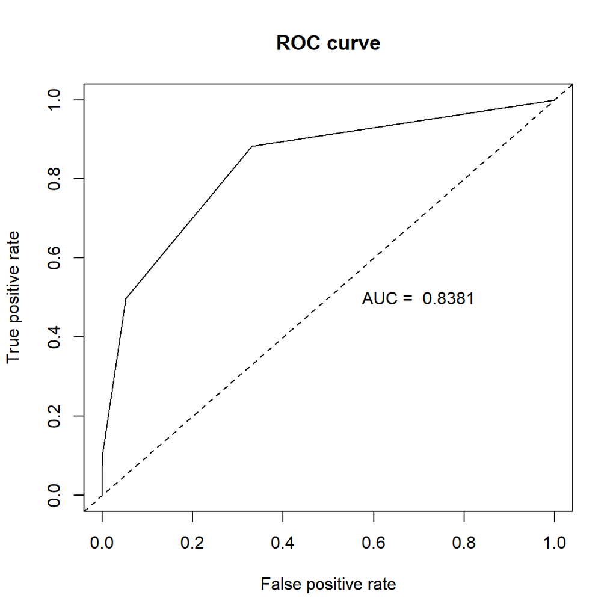

```
## $AUC
## [1] 0.8380742
```

```r
ROC.plot(Pred.prob[,2], Actual)
```

### 예제 데이터 분석: `iris`

```r
head(iris)
```

```
##   Sepal.Length Sepal.Width Petal.Length Petal.Width Species
## 1          5.1         3.5          1.4         0.2  setosa
## 2          4.9         3.0          1.4         0.2  setosa
## 3          4.7         3.2          1.3         0.2  setosa
## 4          4.6         3.1          1.5         0.2  setosa
## 5          5.0         3.6          1.4         0.2  setosa
## 6          5.4         3.9          1.7         0.4  setosa
```

```r
summary(iris)
```

```
##   Sepal.Length    Sepal.Width     Petal.Length    Petal.Width
##  Min.   :4.300   Min.   :2.000   Min.   :1.000   Min.   :0.100
##  1st Qu.:5.100   1st Qu.:2.800   1st Qu.:1.600   1st Qu.:0.300
##  Median :5.800   Median :3.000   Median :4.350   Median :1.300
##  Mean   :5.843   Mean   :3.057   Mean   :3.758   Mean   :1.199
##  3rd Qu.:6.400   3rd Qu.:3.300   3rd Qu.:5.100   3rd Qu.:1.800
##  Max.   :7.900   Max.   :4.400   Max.   :6.900   Max.   :2.500
##        Species
##  setosa    :50
##  versicolor:50
##  virginica :50
##
##
##
```

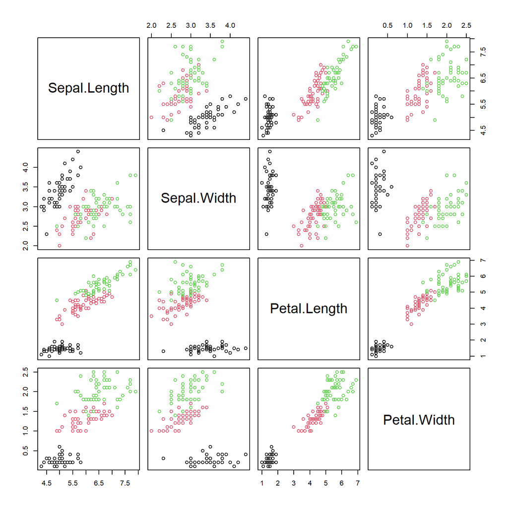

```r
pairs(iris[,-5], col = iris$Species)
```

`iris` 데이터의 `Species`를 예측하는 문제를 생각해보자. `adult` 데이터 분석 때와 달리 다항분류 문제이다.

우선 데이터를 5:5의 비율로 훈련데이터와 시험데이터로 쪼갠다.

```r
tr <- c(1:25, 51:75, 101:125)
iris.tr <- iris[tr,]
iris.te <- iris[-tr,]
```

훈련데이터를 사용해 의사결정나무를 학습시켜보자.

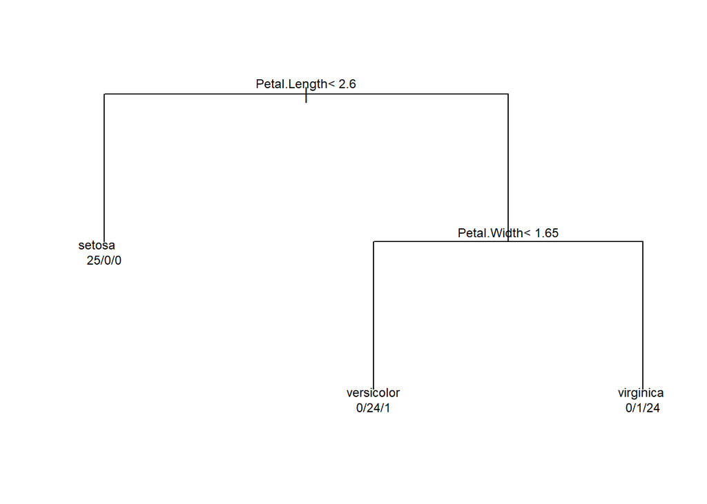

```r
library(rpart)
tree.fit <- rpart(Species ~ ., data = iris.tr)
par(xpd = TRUE)
plot(tree.fit, uniform = TRUE)
text(tree.fit, use.n = TRUE, cex = 0.75)
```

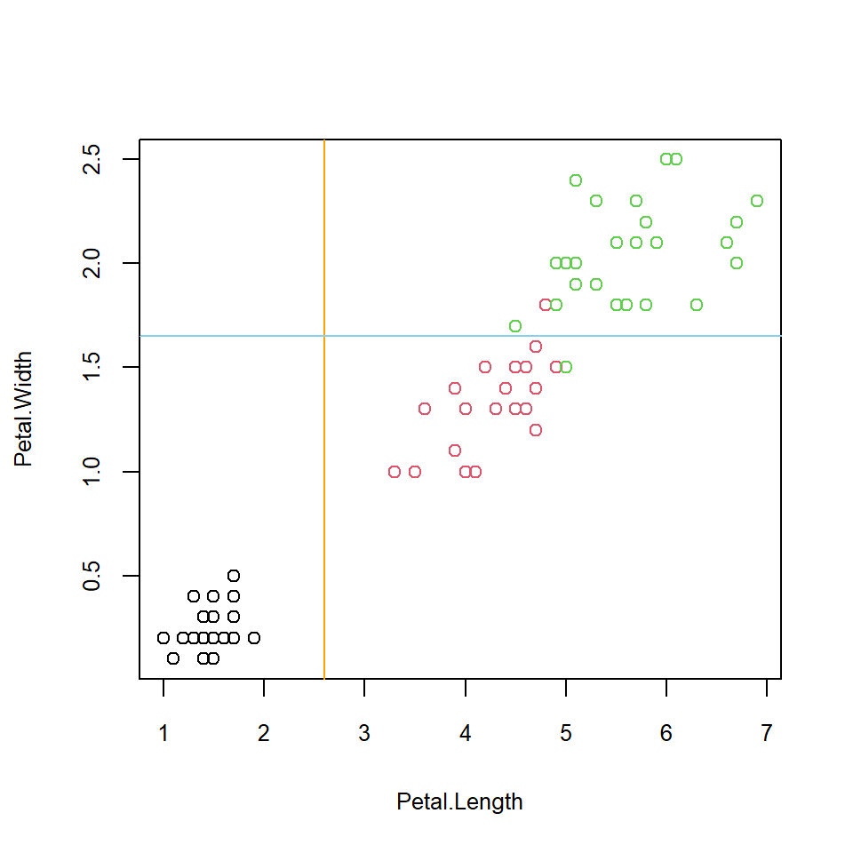

```r
with(iris.tr, plot(Petal.Length, Petal.Width, col = Species, cex.lab = 0.8, cex.axis = 0.8))
abline(v = 2.6, col = "orange")
abline(h = 1.65, col = "skyblue")
```

시험데이터에 대해 예측을 시행하고 성능을 확인해보자.

```r
Actual <- iris.te[,5]
Predicted <- predict(tree.fit, newdata = iris.te, type = "class")
table(Actual, Predicted)
```

```
##             Predicted
## Actual       setosa versicolor virginica
##   setosa         25          0         0
##   versicolor      0         24         1
##   virginica       0          3        22
```

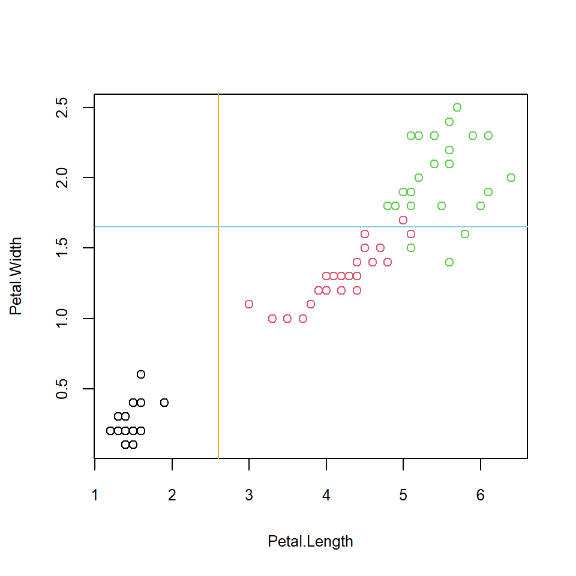

```r
with(iris.te, plot(Petal.Length, Petal.Width, col = Species, cex.lab = 0.8, cex.axis = 0.8))
abline(v = 2.6, col = "orange")
abline(h = 1.65, col = "skyblue")
```

## $k$-최근접이웃 방법

**$k$-최근접 방법($k$-nearest neighbor methods)**은 각 개체로부터 가장 가까운 거리에 있는 $k$개의 훈련데이터 개체의 타겟변수의 평균(또는 투표)을 사용해 해당 개체의 타겟변수의 값(또는 클래스)를 예측하는 방법이다. 개체 간 거리를 예측변수를 통해 측정한 결과를 이용하는 방법이므로, 예측변수별 단위 또는 척도에 의한 영향을 받지 않도록 **표준화를 실시한 후 분석**하는 것이 좋다. 그리고 **$k$의 선택**에 따라 예측 결과가 달라지므로 미세조정(tuning)이 필요하다.

### 예제 데이터 분석: `iris`

`class` 패키지의 `knn()`를 사용해 분석을 실시해보자. $k$의 값은 3으로 선택한다. 우선 네 개의 예측변수에 대해 표준화를 실시하지 않은 경우의 예측 결과이다.

```r
library(class)

res <- knn(train = iris.tr[,-5],
           test = iris.te[,-5],
           cl = iris.tr[,5], k = 3)
table(Actual = iris.te[,5], Predicted = res)
```

```
##             Predicted
## Actual       setosa versicolor virginica
##   setosa         25          0         0
##   versicolor      0         23         2
##   virginica       0          4        21
```

시험데이터에 대한 오분류율이 8%($=6/75$)로 나타났다.

이번에는 변수별 표준화(`scale()` 함수를 이용하면 간단하다)를 실시한 경우의 예측 결과를 살펴보자.

```r
res <- knn(train = scale(iris.tr[,-5]),
           test = scale(iris.te[,-5]),
           cl = iris.tr[,5], k = 3)
table(Actual = iris.te[,5], Predicted = res)
```

```
##             Predicted
## Actual       setosa versicolor virginica
##   setosa         24          1         0
##   versicolor      0         23         2
##   virginica       0          0        25
```

## 나이브베이즈

베이지안 통계학은 관심이 있는 모든 것(모수, 결측치 등)들은 불확실하며 이 불확실의 정도는 확률을 이용해 표현된다는 가정으로부터 출발한다. 따라서 베이지안 통계학의 목표는 주어진 자료를 통하여 관심의 대상이 되는 모수의 불확실성(uncertainty)을 확률분포로 나타내는 것이다. 이 때, 모수의 불확실성에 대한 주관적인 견해를 확률로써 표현한 것을 **사전확률(prior probability)**이라 하며, 사전분포와 실험의 결과를 종합하여 새로이 구하여진 모수의 불확실성을 나타낸 확률을 **사후확률(posterior probability)**이라 한다. 즉, 베이지안 추론의 목표는 사전분포를 데이터를 활용해 사후분포로 갱신하는 것이라 할 수 있다.

**나이브베이즈 분류기(Naive Bayes classifier)**는

1. 클래스별 사전확률을 $P(C_1)$, $P(C_2)$, $\cdots$, $P(C_K)$을
2. 데이터에 의해 주어지는 우도(likelihood) $P({\mathbf x}|C_1)$, $P({\mathbf x}|C_2)$, $\cdots$, $P({\mathbf x}|C_K)$와 베이즈 정리를 이용해 결합해,
3. 클래스별 사후확률 $P(C_1|{\mathbf x})$, $P(C_2|{\mathbf x})$, $\cdots$, $P(C_K|{\mathbf x})$을 계산하고

$$\begin{eqnarray*}
P(C_1|{\mathbf x}) &=& \frac{P(C_1)P({\mathbf x}|C_1)}
{\sum_{k=1}^K P(C_k)P({\mathbf x}|C_k)},\\
P(C_2|{\mathbf x}) &=& \frac{P(C_2)P({\mathbf x}|C_2)}
{\sum_{k=1}^K P(C_k)P({\mathbf x}|C_k)},\\
& & \vdots \\
P(C_K|{\mathbf x}) &=& \frac{P(C_K)P({\mathbf x}|C_K)}
{\sum_{k=1}^K P(C_k)P({\mathbf x}|C_k)}
\end{eqnarray*}$$

4. 클래스별 사후확률을 비교해 가장 높은 클래스로 분류

하는 알고리즘이다. 튜닝이 필요한 하이퍼파라미터가 없고, 비교적 차원 문제에 영향을 받지 않는다는 장점이 있다.

### 예제 데이터 분석: `iris`

```r
library(e1071)
NB <- naiveBayes(Species ~ ., data = iris.tr)
Predicted <- predict(NB, newdata = iris.te, type = "class")
table(iris.te$Species, Predicted)
```

```
##             Predicted
##              setosa versicolor virginica
##   setosa         25          0         0
##   versicolor      0         24         1
##   virginica       0          2        23
```